# Coursera - Practical Machine Learning - Jeff Baker - Course Project

Jeff Baker

8/4/2019

## Study Reference

Six young health participants were asked to perform one set of 10 repetitions of the Unilateral Dumbbell Biceps Curl in five different fashions:

- Exactly according to the specification (Class A)
- Throwing the elbows to the front (Class B)
- Tifting the dumbbell only halfway (Class C)
- Lowering the dumbbell only halfway (Class D)
- Throwing the hips to the front (Class E)

I believe my out of error sample rate will be approximately 78%. This is what was obtained in the original study.

The first thing I did was to read the original study for insight into the process where it is explained that **17** features were selected, RF were used etc: http://groupware.les.inf.puc-rio.br/public/papers/2013.Velloso.QAR-WLE.pdf

**Belt** * belt- roll mean * belt- roll variance * belt- accelerometer - maximum * belt- accelerometer - range * belt- accelerometer - variance * belt- gyro variance * belt- magnetometer variance

**Arm** * arm- accelerometer variance * arm- magnetometer - maximum * arm- magnetometer - minimum

**Dumbell** * dumbell- acceleration - maximum * dumbell- gyro variance * dumbell- magnetometer - maximum * dumbell- magnetometer - minimum

**Glove** * glove- sum of pitch * glove- gyro maximum * glove- gyro minimum

## Implemenation

```r
library(caret)
library(randomForest)
```

Download the CSVs and load into dataframes

```r
pmlTraining = read.csv("pml-training.csv")
pmlTesting = read.csv("pml-testing.csv")
```

What do our data sets look like?

```r
dim(pmlTraining)
```

```
## [1] 19622   160
```

```r
dim(pmlTesting)
```

```
## [1]  20 160
```

Set the seed as Random Forest models are random and we want this reproducible

```r
set.seed(1)
```

What are the first 5 columns?

```r
str(pmlTraining, list.len = 5)
```

```
## 'data.frame':    19622 obs. of  160 variables:
##  $ X                       : int  1 2 3 4 5 6 7 8 9 10 ...
##  $ user_name               : Factor w/ 6 levels "adelmo","carlitos",..: 2 2 2 2 2 2 2 2 2 2 ...
##  $ raw_timestamp_part_1    : int  1323084231 1323084231 1323084231 1323084232 1323084232 1323084232 1323084232 1323084232 1323084232 1323084232 ...
##  $ raw_timestamp_part_2    : int  788290 808298 820366 120339 196328 304277 368296 440390 484323 484434 ...
##  $ cvtd_timestamp          : Factor w/ 20 levels "02/12/2011 13:32",..: 9 9 9 9 9 9 9 9 9 9 ...
##   [list output truncated]
```

```r
str(pmlTesting, list.len = 5)
```

```
## 'data.frame':    20 obs. of  160 variables:
##  $ X                       : int  1 2 3 4 5 6 7 8 9 10 ...
##  $ user_name               : Factor w/ 6 levels "adelmo","carlitos",..: 6 5 5 1 4 5 5 5 2 3 ...
##  $ raw_timestamp_part_1    : int  1323095002 1322673067 1322673075 1322832789 1322489635 1322673149 1322673128 1322673076 1323084240 1322837822 ...
##  $ raw_timestamp_part_2    : int  868349 778725 342967 560311 814776 510661 766645 54671 916313 384285 ...
##  $ cvtd_timestamp          : Factor w/ 11 levels "02/12/2011 13:33",..: 5 10 10 1 6 11 11 10 3 2 ...
##   [list output truncated]
```

Remove the first 5 columns as they are not predictors and will skew the result - especially variable importance

```r
pmlTraining.missingfirstfive <- pmlTraining[ -c(1:5)]
pmlTesting.missingfirstfive <- pmlTesting[ -c(1:5)]
dim(pmlTraining.missingfirstfive)
```

```
## [1] 19622   155
```

```r
dim(pmlTesting.missingfirstfive)
```

```
## [1]  20 155
```

What are all the column names with NAs in the training and test sets? Need to elminate empty values from the test set from the training set Get a list of columns from test which have empty values

```r
colnamesNATrain <- colnames(pmlTraining.missingfirstfive)[colSums(is.na(pmlTraining.missingfirstfive)) > 0]
colnamesNATest <- colnames(pmlTesting.missingfirstfive)[colSums(is.na(pmlTesting.missingfirstfive)) > 0]
```

Get a count of NAs for all columns because RFs and other comparison functions don’t work with NAs

```r
length(colnamesNATrain)
```

```
## [1] 67
```

```r
length(colnamesNATest)
```

```
## [1] 100
```

Remove columns with NA in the training set from the training set

```r
pmlTraining.missingfirstfive.nonas <- subset(pmlTraining.missingfirstfive, select=colMeans(is.na(pmlTraining.missingfirstfive)) == 0)

dim(pmlTraining.missingfirstfive.nonas)
```

```
## [1] 19622    88
```

Match the NA columns from test with those columns in training

```r
idx <- match(colnamesNATest, names(pmlTraining.missingfirstfive.nonas))
idx <- idx[!is.na(idx)]
```

```r
pmlTraining.missingfirstfive.nonas2 <- pmlTraining.missingfirstfive.nonas[,-idx]
dim(pmlTraining.missingfirstfive.nonas2)
```

```
## [1] 19622    55
```

Random Forest cannot handle categorical predictors with more than 53 categories Remove columns with factors higher than 53

```r
pmlTraining.smallFactors <- pmlTraining.missingfirstfive.nonas2[sapply(pmlTraining.missingfirstfive.nonas2, nlevels) <= 53]

dim(pmlTraining.smallFactors)
```

```
## [1] 19622    55
```

```r
pmlTraining.smallFactors <- transform(pmlTraining.smallFactors, magnet_dumbbell_z = as.integer(magnet_dumbbell_z))
pmlTraining.smallFactors <- transform(pmlTraining.smallFactors, magnet_forearm_y  = as.integer(magnet_forearm_y))
pmlTraining.smallFactors <- transform(pmlTraining.smallFactors, magnet_forearm_z = as.integer(magnet_forearm_z))
```

More clean up of the Testing set:

Remove columns with NA

```r
pmlTesting.missingfirstfive.nonas <- subset(pmlTesting.missingfirstfive, select=colMeans(is.na(pmlTesting.missingfirstfive)) == 0)
dim(pmlTesting.missingfirstfive.nonas)
```

```
## [1] 20 55
```

Remove columns with factors higher than 53

```r
pmlTesting.smallFactors <- pmlTesting.missingfirstfive.nonas[sapply(pmlTesting.missingfirstfive.nonas, nlevels) <= 53]

dim(pmlTesting.smallFactors)
```

```
## [1] 20 55
```

Update new_window column in testing dataset to have 2 levels to match training

```r
str(pmlTesting.smallFactors$new_window)
```

```
##  Factor w/ 1 level "no": 1 1 1 1 1 1 1 1 1 1 ...
```

```r
levels(pmlTesting.smallFactors$new_window) <- levels(pmlTraining.smallFactors$new_window)

str(pmlTesting.smallFactors$new_window)
```

```
##  Factor w/ 2 levels "no","yes": 1 1 1 1 1 1 1 1 1 1 ...
```

As the test set does not contain the classe column and contains the problem_id columns instead, we need to split our training data into training and testing sets

Use createDataPartition to split training into 3/4 of the original training set and testing into 1/4th the original training set

```r
inTrain = createDataPartition(pmlTraining.smallFactors$classe, p = 3/4, list= FALSE)
training = pmlTraining.smallFactors[ inTrain,]
testing = pmlTraining.smallFactors[-inTrain,]
```

This article explains how to include importance=T and scale = F to get the variable importance from the Random Forest

https://explained.ai/rf-importance/

Build a random forest model, handling any remaining NAs with a roughfix

```r
training.rf =randomForest(classe~., data=training,importance=T, na.action = na.roughfix)

training.rf
```

```
##
## Call:
##  randomForest(formula = classe ~ ., data = training, importance = T,      na.action = na.roughfix)
##                Type of random forest: classification
##                      Number of trees: 500
## No. of variables tried at each split: 7
##
##         OOB estimate of  error rate: 0.24%
## Confusion matrix:
##      A    B    C    D    E  class.error
## A 4184    1    0    0    0 0.0002389486
## B    3 2843    2    0    0 0.0017556180
## C    0   11 2556    0    0 0.0042851578
## D    0    0   14 2397    1 0.0062189055
## E    0    0    0    4 2702 0.0014781966
```

What does our Random Forest model tell us about the OOB error rate and the class.error rate? They’re small.

Predict the Random Forest model against the testing data split from the original training data. Why Random Forest?:

1. Because that is what the original study used and
2. Because it works best for this kind of data and
3. Does not require cross validation, because of OOB error estimates (linked article explaining this)

https://www.stat.berkeley.edu/~breiman/RandomForests/cc_home.htm#ooberr

Get the variable importance by permutation

```r
imp <- importance(training.rf, type=1, scale = F)

imp
```

```
##                      MeanDecreaseAccuracy
## new_window                  -8.506310e-06
## num_window                   1.556104e-01
## roll_belt                    1.113796e-01
## pitch_belt                   8.709708e-02
## yaw_belt                     1.014470e-01
## total_accel_belt             2.385603e-02
## gyros_belt_x                 1.197439e-02
## gyros_belt_y                 1.422239e-02
## gyros_belt_z                 3.236880e-02
## accel_belt_x                 1.737941e-02
## accel_belt_y                 2.131692e-02
## accel_belt_z                 3.595276e-02
## magnet_belt_x                2.730002e-02
## magnet_belt_y                4.368830e-02
## magnet_belt_z                4.946982e-02
## roll_arm                     3.697121e-02
## pitch_arm                    1.736512e-02
## yaw_arm                      1.954495e-02
## total_accel_arm              7.514214e-03
## gyros_arm_x                  9.690239e-03
## gyros_arm_y                  9.334252e-03
## gyros_arm_z                  3.974267e-03
## accel_arm_x                  3.115977e-02
## accel_arm_y                  1.476069e-02
## accel_arm_z                  1.134118e-02
## magnet_arm_x                 4.388710e-02
## magnet_arm_y                 2.999924e-02
## magnet_arm_z                 1.531224e-02
## roll_dumbbell                5.670024e-02
## pitch_dumbbell               2.463595e-02
## yaw_dumbbell                 3.874681e-02
## total_accel_dumbbell         3.809902e-02
## gyros_dumbbell_x             9.013732e-03
## gyros_dumbbell_y             2.377438e-02
## gyros_dumbbell_z             4.061930e-03
## accel_dumbbell_x             3.939679e-02
## accel_dumbbell_y             5.413719e-02
## accel_dumbbell_z             4.808992e-02
## magnet_dumbbell_x            9.669313e-02
## magnet_dumbbell_y            1.089164e-01
## magnet_dumbbell_z            1.069259e-01
## roll_forearm                 1.039738e-01
## pitch_forearm                7.466019e-02
## yaw_forearm                  1.782439e-02
## total_accel_forearm          7.427821e-03
## gyros_forearm_x              5.305506e-03
## gyros_forearm_y              7.044395e-03
## gyros_forearm_z              4.591878e-03
## accel_forearm_x              4.289542e-02
## accel_forearm_y              1.363227e-02
## accel_forearm_z              3.060258e-02
## magnet_forearm_x             2.082847e-02
## magnet_forearm_y             2.085806e-02
## magnet_forearm_z             2.626592e-02
```

Visually make sure that none of the empty training and test columns are any of those with high permutation importance

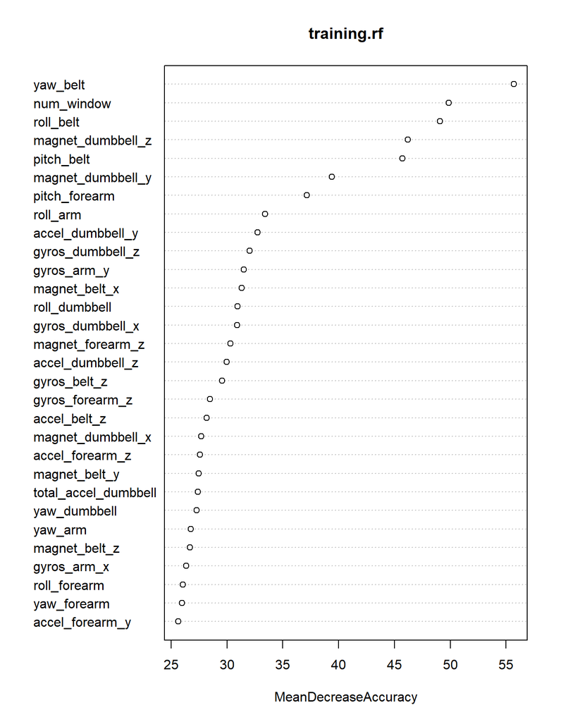

```r
varImpPlot(training.rf,type = 1)
```

Predict against our split testing portion of our training set

```r
predictTF <- predict(training.rf, newdata = testing)
```

What does the confusionMatrix tell us about Accuracy, Kappa, CI, Sensitivity and Specificity? **All very good!**

```r
confusionMatrix(testing$classe,predictTF)
```

```
## Confusion Matrix and Statistics
##
##           Reference
## Prediction    A    B    C    D    E
##          A 1395    0    0    0    0
##          B    1  948    0    0    0
##          C    0    7  848    0    0
##          D    0    0    9  795    0
##          E    0    0    0    5  896
##
## Overall Statistics
##
##                Accuracy : 0.9955
##                  95% CI : (0.9932, 0.9972)
##     No Information Rate : 0.2847
##     P-Value [Acc > NIR] : < 2.2e-16
##
##                   Kappa : 0.9943
##
##  Mcnemar's Test P-Value : NA
##
## Statistics by Class:
##
##                      Class: A Class: B Class: C Class: D Class: E
## Sensitivity            0.9993   0.9927   0.9895   0.9938   1.0000
## Specificity            1.0000   0.9997   0.9983   0.9978   0.9988
## Pos Pred Value         1.0000   0.9989   0.9918   0.9888   0.9945
## Neg Pred Value         0.9997   0.9982   0.9978   0.9988   1.0000
## Prevalence             0.2847   0.1947   0.1748   0.1631   0.1827
## Detection Rate         0.2845   0.1933   0.1729   0.1621   0.1827
## Detection Prevalence   0.2845   0.1935   0.1743   0.1639   0.1837
## Balanced Accuracy      0.9996   0.9962   0.9939   0.9958   0.9994
```

Now let’s use the entire training dataset, build a Random Forest and predict it against problem_id in the test data. The number of classifiers could be reduced to the top 17 or so, but given the high accuracy, this seems like it would offer diminishing returns.

```r
pmlTraining.rf =randomForest(classe~., data=pmlTraining.smallFactors,importance=T, na.action = na.roughfix)

pmlTraining.rf
```

```
##
## Call:
##  randomForest(formula = classe ~ ., data = pmlTraining.smallFactors,      importance = T, na.action = na.roughfix)
##                Type of random forest: classification
##                      Number of trees: 500
## No. of variables tried at each split: 7
##
##         OOB estimate of  error rate: 0.14%
## Confusion matrix:
##      A    B    C    D    E  class.error
## A 5579    0    0    0    1 0.0001792115
## B    3 3793    1    0    0 0.0010534633
## C    0    7 3415    0    0 0.0020455874
## D    0    0   13 3202    1 0.0043532338
## E    0    0    0    2 3605 0.0005544774
```

What does our Random Forest model tell us about the OOB error rate and the class.error rate? They’re small.

Predict using our RF model which uses the entire training set against the entire 20 record test set

```r
predictTestForest <- predict(pmlTraining.rf, newdata = pmlTesting.smallFactors)
```

A consufionMatrix won’t work because both data sets don’t have classe.

So instead, we’ll look at our results in two different formats.

```r
predictTestForest
```

```
##  1  2  3  4  5  6  7  8  9 10 11 12 13 14 15 16 17 18 19 20
##  B  A  B  A  A  E  D  B  A  A  B  C  B  A  E  E  A  B  B  B
## Levels: A B C D E
```

```r
table(pmlTesting.smallFactors$problem_id, predictTestForest)
```

```
##     predictTestForest
##      A B C D E
##   1  0 1 0 0 0
##   2  1 0 0 0 0
##   3  0 1 0 0 0
##   4  1 0 0 0 0
##   5  1 0 0 0 0
##   6  0 0 0 0 1
##   7  0 0 0 1 0
##   8  0 1 0 0 0
##   9  1 0 0 0 0
##   10 1 0 0 0 0
##   11 0 1 0 0 0
##   12 0 0 1 0 0
##   13 0 1 0 0 0
##   14 1 0 0 0 0
##   15 0 0 0 0 1
##   16 0 0 0 0 1
##   17 1 0 0 0 0
##   18 0 1 0 0 0
##   19 0 1 0 0 0
##   20 0 1 0 0 0
```